# Stat 475 Final Project

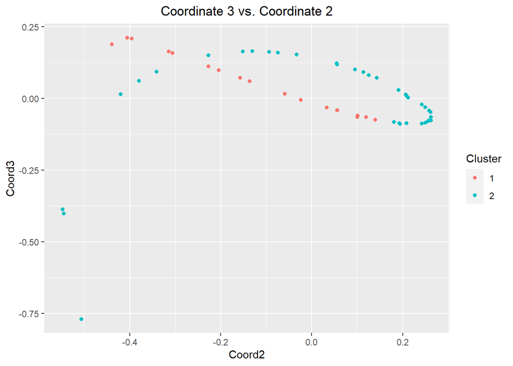

```r
##Plot Coordinates 2 and 3
ggplot(Xpoints, aes(x = Coord2, y = Coord3, color = Cluster)) + geom_point() + ggtitle("Coordinate 3 vs. Coordinate 2") + theme(plot.title = element_text(hjust = 0.5))
```

```r
##See Which cluster is further from developing than the other by using the variables we found were
averagecountryvalues$Cluster <- cutree(HClust, 2)
averagecountryvalues %>% dplyr::group_by(Cluster) %>% dplyr::summarise_at(vars('GDP.per.capita', "Corruption.Index", "Crude.death.rate", "HDI", "Life.expectancy"), mean)
```

```
## # A tibble: 2 x 6
##   Cluster GDP.per.capita Corruption.Index Crude.death.rate   HDI Life.expectancy
## *   <int>          <dbl>            <dbl>            <dbl> <dbl>           <dbl>
## 1       1         15700.             49.0          0.00659 0.738            73.8
## 2       2          4373.             32.5          0.00769 0.633            67.8
```

```r
##See which countries are in Cluster 2 which are the countries further away from developing
averagecountryvalues[averagecountryvalues$Cluster == 2, ]$Country
```

```
##  [1] Angola             Argentina          Bolivia            Brazil
##  [5] Cameroon           Chile              China              Colombia
##  [9] Dominican Republic Ecuador            Egypt              Ghana
## [13] Guatemala          Haiti              India              Indonesia
## [17] Ivory Coast        Kenya              Madagascar         Malawi
## [21] Malaysia           Mexico             Morocco            Pakistan
## [25] Peru               Philippines        Romania            Senegal
## [29] South Africa       South Korea        Sri Lanka          Tanzania
## [33] Thailand           Tunisia            Turkey             Uganda
## [37] Venezuela          Vietnam            Zambia
## 82 Levels: Albania Angola Argentina Australia Austria Belgium ... Zambia
```

```r
##Countries in Cluster 1
averagecountryvalues[averagecountryvalues$Cluster == 1, ]$Country
```

```
##  [1] Albania             Botswana            Costa Rica
##  [4] El Salvador         Honduras            Hong Kong
##  [7] Israel              Jamaica             Jordan
## [10] Luxembourg          Mauritius           Namibia
## [13] Nicaragua           Panama              Paraguay
## [16] Singapore           Trinidad and Tobago Uruguay
## 82 Levels: Albania Angola Argentina Australia Austria Belgium ... Zambia
```

To further investigate what are the biggest problems developing countries are facing in becoming developed I decided to use logistic regression with a response variable of status to find which variables effect status of a country the most. Specifically I performed logistic regression on data where a single observation is from a country in a given year that could be between the years of 2002-2016. First, I split my data into a training and test set using the function CreateDataPartition, specifically to keep the proportion of status = “developed” the same between the test set and the training set. My training set contained 70 percent of the observations from the full data set and my test set contained 30 percent of the observations from the full data set. After my data was split into a training and test set I fit a logistic regression model on my training set with the response variable being status and the explanatory variables being all other variables from the sample data file except for Country and Date. I then performed Backward Selection using AIC on the full model I just fit and found that optimal variables chosen by Backward Selection were Annual.GDP, GDP.per.capita, Debt.Per.Capita, Imports, CO2.Tons.per.capita, and Continent. I then fit a logistic regression model on my training dataset with the response variable being status and the explanatory variables being GDP.per.capita(I didn’t use annual.GDP because of high correlation with GDP.per.capita), Debt.Per.Capita, Imports, CO2.tons.per.capita, and Continent. After fitting this logistic regression model using the variables found from Backward selection I then found the predicted classes of the status variable on the test set using this logistic regression model. From these predictions I found that the misclassification rate of the logistic regression model found using Backward Selection was 0.01630435. The confusion matrix below between the actual values from the test set and the predicted values using the logistic regression model with backward selection shows that the model misclassified 3 out of 112 actual “Developed” countries and also misclassified 3 out of 256 actual “Developing” Countries. I then decided to fit a random forest with status as my response variable and every variable in the data set except for Country and Date as my explanatory variables on my training set. I set the number of trees to 1500 and the nodesize to 5, meaning that a terminal node could not have less than 5 observations. I then used this randomForest to predict status on my test set and found that the misclassifcation Error Rate was 0. This means that my random forest that I fit on the training set with all the predictors in the dataset except for country and Date did not misclassify one single observation in the test set. From using the importance plot below and the meanDecreaseGini as this random forest is used for classificatio, you can see that the variables that were most important in the random forest model to predicting status were Expenditure.Per.Capita, Continent, Debt.Per.Capita, HDI, and GDP.Per.Capita. When comparing the performance of the logistic regression model found using backward selection and the random forest on the test set, the random forest performs better as it has a misclassification error rate of 0 and the logistic regression model has a misclassification error rate of 0.01630435. This could be due to a multitude of factors one of which could be that actual decision boundary is irregular and non linear so the random forest as a non-parametric model will perform better. From these two different classification techniques the variables that I found are most important to classifying the status of a country are Annual.GDP, GDP.per.capita, Debt.Per.Capita, Imports, CO2.Tons.per.capita,Continent, HDI, and Expenditure.per.capita. From these variables only Annual.GDP, GDP.per.capita, Imports, Expenditure.Per.Capita, and HDI are actually problems that these developing countries are facing and variables that they need to see a drastic increase in.

```r
##Set seed so we get the same random sample every time
set.seed(1)
dim(data)
```

```
## [1] 1230   22
```

```r
##Use Create Data Partition to create training and test set that have the close to the same proportion of status = "Developing" 70 percent of the data is also going in the training set
trainindex <- createDataPartition(data$status, p = 0.7, list = FALSE)

##Use backward selection to fit a logistic regression model
LogRegFull <- glm(data = data[trainindex, ], status ~. - Country -Date, family = "binomial")
LogRegBackwardSelection <- step(LogRegFull, direction = "backward")
```

```
## Start:  AIC=1129.31
## status ~ (Country + Date + Annual.GDP + GDP.per.capita + Debt +
##     Debt.Per.Capita + Deficit...M... + Expenditure..M... + Expenditure.Per.Capita +
##     Corruption.Index + Exports + Exports...GDP + Imports + Imports...GDP +
##     Population + Fertility.Rate + Crude.death.rate + HDI + Life.expectancy +
##     CO2.Tons.per.capita + Continent) - Country - Date
```

```
##                          Df Deviance     AIC
## - Expenditure.Per.Capita  1     0.00   46.00
## - Expenditure..M...       1     0.00   46.00
## - Annual.GDP              1     0.00   46.00
## - GDP.per.capita          1     0.00   46.00
## - Deficit...M...          1   576.70  622.70
## - Exports...GDP           1   792.96  838.96
## - Debt                    1   937.13  983.13
## - Exports                 1   937.13  983.13
## - HDI                     1   937.13  983.13
## - Population              1  1009.22 1055.22
## - Fertility.Rate          1  1081.31 1127.31
## <none>                       1081.31 1129.31
## - Debt.Per.Capita         1  1153.40 1199.40
## - Imports...GDP           1  1225.48 1271.48
## - Life.expectancy         1  1441.75 1487.75
## - CO2.Tons.per.capita     1  1441.75 1487.75
## - Corruption.Index        1  1585.92 1631.92
## - Crude.death.rate        1  1658.01 1704.01
## - Continent               5  2450.97 2488.97
## - Imports                 1  2450.97 2496.97
```

```
##
## Step:  AIC=46
## status ~ Annual.GDP + GDP.per.capita + Debt + Debt.Per.Capita +
##     Deficit...M... + Expenditure..M... + Corruption.Index + Exports +
##     Exports...GDP + Imports + Imports...GDP + Population + Fertility.Rate +
##     Crude.death.rate + HDI + Life.expectancy + CO2.Tons.per.capita +
##     Continent
```

```
##                       Df Deviance     AIC
## - Corruption.Index     1     0.00   44.00
## - Life.expectancy      1     0.00   44.00
## - Deficit...M...       1     0.00   44.00
## - Expenditure..M...    1     0.00   44.00
## - HDI                  1     0.00   44.00
## - Population           1     0.00   44.00
## - Crude.death.rate     1     0.00   44.00
## - Exports...GDP        1     0.00   44.00
## - Fertility.Rate       1     0.00   44.00
## - Imports...GDP        1     0.00   44.00
## <none>                       0.00   46.00
## - Continent            5    71.82  107.82
## - Exports              1   865.05  909.05
## - CO2.Tons.per.capita  1   937.13  981.13
## - Debt.Per.Capita      1  1081.31 1125.31
## - Debt                 1  1369.66 1413.66
## - GDP.per.capita       1  1513.83 1557.83
## - Annual.GDP           1  1730.10 1774.10
## - Imports              1  1946.36 1990.36
```

```
##
## Step:  AIC=44
## status ~ Annual.GDP + GDP.per.capita + Debt + Debt.Per.Capita +
##     Deficit...M... + Expenditure..M... + Exports + Exports...GDP +
##     Imports + Imports...GDP + Population + Fertility.Rate + Crude.death.rate +
##     HDI + Life.expectancy + CO2.Tons.per.capita + Continent
```

```
##                       Df Deviance     AIC
## - HDI                  1      0.0    42.0
## - Deficit...M...       1      0.0    42.0
## - Expenditure..M...    1      0.0    42.0
## - Life.expectancy      1      0.0    42.0
## - Population           1      0.0    42.0
## - Crude.death.rate     1      0.0    42.0
## - Exports...GDP        1      0.0    42.0
## - Fertility.Rate       1      0.0    42.0
## - Debt                 1      0.0    42.0
## - Imports...GDP        1      0.0    42.0
## - Exports              1      0.0    42.0
## - Annual.GDP           1      0.0    42.0
## <none>                        0.0    44.0
## - Continent            5     72.6   106.6
## - CO2.Tons.per.capita  1   1009.2  1051.2
## - Imports              1   1297.6  1339.6
## - Debt.Per.Capita      1   2667.2  2709.2
## - GDP.per.capita       1  17949.7 17991.7
```

```
##
## Step:  AIC=42
## status ~ Annual.GDP + GDP.per.capita + Debt + Debt.Per.Capita +
##     Deficit...M... + Expenditure..M... + Exports + Exports...GDP +
##     Imports + Imports...GDP + Population + Fertility.Rate + Crude.death.rate +
##     Life.expectancy + CO2.Tons.per.capita + Continent
```

```
##                       Df Deviance     AIC
## - Deficit...M...       1      0.0    40.0
## - Expenditure..M...    1      0.0    40.0
## - Life.expectancy      1      0.0    40.0
## - Crude.death.rate     1      0.0    40.0
## - Population           1      0.0    40.0
## - Exports...GDP        1      0.0    40.0
## - Fertility.Rate       1      0.0    40.0
## - Exports              1      0.0    40.0
## <none>                        0.0    42.0
## - Continent            5    118.7   150.7
## - Imports              1   1225.5  1265.5
## - Debt                 1   1369.7  1409.7
## - CO2.Tons.per.capita  1   1369.7  1409.7
## - Annual.GDP           1   1513.8  1553.8
## - GDP.per.capita       1   4901.9  4941.9
## - Debt.Per.Capita      1  15426.7 15466.7
## - Imports...GDP        1  18310.2 18350.2
```

```
##
## Step:  AIC=40
## status ~ Annual.GDP + GDP.per.capita + Debt + Debt.Per.Capita +
##     Expenditure..M... + Exports + Exports...GDP + Imports + Imports...GDP +
##     Population + Fertility.Rate + Crude.death.rate + Life.expectancy +
##     CO2.Tons.per.capita + Continent
```

```
##                       Df Deviance    AIC
## - Expenditure..M...    1      0.0   38.0
## - Life.expectancy      1      0.0   38.0
## - Crude.death.rate     1      0.0   38.0
## - Population           1      0.0   38.0
## - Exports...GDP        1      0.0   38.0
## - Fertility.Rate       1      0.0   38.0
## - Imports...GDP        1      0.0   38.0
## - Exports              1      0.0   38.0
## - Annual.GDP           1      0.0   38.0
## <none>                        0.0   40.0
## - Continent            5    118.7  148.7
## - CO2.Tons.per.capita  1   1081.3 1119.3
## - Imports              1   1153.4 1191.4
## - Debt                 1   1946.4 1984.4
## - GDP.per.capita       1   2090.5 2128.5
## - Debt.Per.Capita      1   2451.0 2489.0
```

```
##
## Step:  AIC=38
## status ~ Annual.GDP + GDP.per.capita + Debt + Debt.Per.Capita +
##     Exports + Exports...GDP + Imports + Imports...GDP + Population +
##     Fertility.Rate + Crude.death.rate + Life.expectancy + CO2.Tons.per.capita +
##     Continent
```

```
##                       Df Deviance     AIC
## - Life.expectancy      1     0.00   36.00
## - Crude.death.rate     1     0.00   36.00
## - Population           1     0.00   36.00
## - Exports...GDP        1     0.00   36.00
## - Fertility.Rate       1     0.00   36.00
## - Imports...GDP        1     0.00   36.00
## - Exports              1     0.00   36.00
## - Annual.GDP           1     0.00   36.00
## <none>                       0.00   38.00
## - GDP.per.capita       1    38.27   74.27
## - Debt.Per.Capita      1    40.83   76.83
## - Continent            5   118.70  146.70
## - Imports              1  1225.48 1261.48
## - CO2.Tons.per.capita  1  1441.75 1477.75
## - Debt                 1  1802.18 1838.18
```

```
##
## Step:  AIC=36
## status ~ Annual.GDP + GDP.per.capita + Debt + Debt.Per.Capita +
##     Exports + Exports...GDP + Imports + Imports...GDP + Population +
##     Fertility.Rate + Crude.death.rate + CO2.Tons.per.capita +
##     Continent
```

```
##                       Df Deviance     AIC
## - Population           1     0.00   34.00
## - Crude.death.rate     1     0.00   34.00
## - Exports...GDP        1     0.00   34.00
## - Imports...GDP        1     0.00   34.00
## - Exports              1     0.00   34.00
## - Annual.GDP           1     0.00   34.00
## - Fertility.Rate       1     0.00   34.00
## - Imports              1     0.00   34.00
## <none>                       0.00   36.00
## - Debt.Per.Capita      1    41.66   75.66
## - GDP.per.capita       1    42.19   76.19
## - Continent            5   168.32  194.32
## - CO2.Tons.per.capita  1  1297.57 1331.57
## - Debt                 1  1513.83 1547.83
```

```
##
## Step:  AIC=34
## status ~ Annual.GDP + GDP.per.capita + Debt + Debt.Per.Capita +
##     Exports + Exports...GDP + Imports + Imports...GDP + Fertility.Rate +
##     Crude.death.rate + CO2.Tons.per.capita + Continent
```

```
##                       Df Deviance     AIC
## - Exports...GDP        1     0.00   32.00
## - Crude.death.rate     1     0.00   32.00
## - Debt                 1     0.00   32.00
## - Imports...GDP        1     0.00   32.00
## - Fertility.Rate       1     0.00   32.00
## <none>                       0.00   34.00
## - Debt.Per.Capita      1    44.39   76.39
## - Continent            5   228.90  252.90
## - Annual.GDP           1  1297.57 1329.57
## - Imports              1  1513.83 1545.83
## - CO2.Tons.per.capita  1  1585.92 1617.92
## - Exports              1  2162.62 2194.62
## - GDP.per.capita       1  2378.88 2410.88
```

```
##
## Step:  AIC=32
## status ~ Annual.GDP + GDP.per.capita + Debt + Debt.Per.Capita +
##     Exports + Imports + Imports...GDP + Fertility.Rate + Crude.death.rate +
##     CO2.Tons.per.capita + Continent
```

```
##                       Df Deviance     AIC
## - Crude.death.rate     1     0.00   30.00
## - Debt                 1     0.00   30.00
## - Imports...GDP        1     0.00   30.00
## - Fertility.Rate       1     0.00   30.00
## - Annual.GDP           1     0.00   30.00
## <none>                       0.00   32.00
## - GDP.per.capita       1    42.26   72.26
## - Debt.Per.Capita      1    44.39   74.39
## - Continent            5   229.78  251.78
## - CO2.Tons.per.capita  1  1658.01 1688.01
## - Exports              1  1874.27 1904.27
## - Imports              1  2883.49 2913.49
```

```
##
## Step:  AIC=30
## status ~ Annual.GDP + GDP.per.capita + Debt + Debt.Per.Capita +
##     Exports + Imports + Imports...GDP + Fertility.Rate + CO2.Tons.per.capita +
##     Continent
```

```
##                       Df Deviance     AIC
## - Debt                 1     0.00   28.00
## - Fertility.Rate       1     0.00   28.00
## - Imports...GDP        1     0.00   28.00
## - Exports              1     0.00   28.00
## <none>                       0.00   30.00
## - Imports              1    12.72   40.72
## - Debt.Per.Capita      1    58.50   86.50
## - Continent            5   341.58  361.58
## - CO2.Tons.per.capita  1  2234.71 2262.71
## - Annual.GDP           1  2306.79 2334.79
## - GDP.per.capita       1  2450.97 2478.97
```

```
##
## Step:  AIC=28
## status ~ Annual.GDP + GDP.per.capita + Debt.Per.Capita + Exports +
##     Imports + Imports...GDP + Fertility.Rate + CO2.Tons.per.capita +
##     Continent
```

```
##                       Df Deviance     AIC
## - Fertility.Rate       1     0.00   26.00
## - Imports...GDP        1     0.00   26.00
## - Exports              1     0.00   26.00
## <none>                       0.00   28.00
## - Imports              1    16.05   42.05
## - Annual.GDP           1    20.93   46.93
## - GDP.per.capita       1    84.68  110.68
## - Debt.Per.Capita      1   103.66  129.66
## - Continent            5   341.63  359.63
## - CO2.Tons.per.capita  1  2018.44 2044.44
```

```
##
## Step:  AIC=26
## status ~ Annual.GDP + GDP.per.capita + Debt.Per.Capita + Exports +
##     Imports + Imports...GDP + CO2.Tons.per.capita + Continent
```

```
##                       Df Deviance     AIC
## - Imports...GDP        1     0.00   24.00
## - Exports              1     0.00   24.00
## <none>                       0.00   26.00
## - Imports              1    17.26   41.26
## - Annual.GDP           1    22.12   46.12
## - GDP.per.capita       1    89.40  113.40
## - Debt.Per.Capita      1   104.31  128.31
## - Continent            5   452.71  468.71
## - CO2.Tons.per.capita  1  1802.18 1826.18
```

```
##
## Step:  AIC=24
## status ~ Annual.GDP + GDP.per.capita + Debt.Per.Capita + Exports +
##     Imports + CO2.Tons.per.capita + Continent
```

```
##                       Df Deviance    AIC
## - Exports              1     0.00  22.00
## <none>                       0.00  24.00
## - Annual.GDP           1    25.43  47.43
## - Imports              1    25.65  47.65
## - CO2.Tons.per.capita  1    67.75  89.75
## - GDP.per.capita       1    98.63 120.63
## - Debt.Per.Capita      1   105.12 127.12
## - Continent            5   470.74 484.74
```

```
##
## Step:  AIC=22
## status ~ Annual.GDP + GDP.per.capita + Debt.Per.Capita + Imports +
##     CO2.Tons.per.capita + Continent
```

```
##                       Df Deviance    AIC
## <none>                       0.00  22.00
## - Imports              1    25.75  45.75
## - Annual.GDP           1    44.16  64.16
## - CO2.Tons.per.capita  1    70.60  90.60
## - GDP.per.capita       1   108.63 128.63
## - Debt.Per.Capita      1   125.44 145.44
## - Continent            5   472.51 484.51
```

```r
##Coefficients Found using Backward Selection
LogRegBackwardSelection$coef
```

```
##            (Intercept)             Annual.GDP         GDP.per.capita
##          -1.171101e+03           2.102193e-03          -3.505072e-02
##        Debt.Per.Capita                Imports    CO2.Tons.per.capita
##           9.934469e-02          -5.148932e-03           9.609465e+01
##          ContinentAsia        ContinentEurope ContinentNorth America
##          -3.114215e+03           7.226007e+02          -1.439311e+03
##       ContinentOceania ContinentSouth America
##           8.524591e+02          -3.691055e+03
```

```r
##Fit the Logistic Regression Model using the variables found using Backward Selection
LogRegBackward <- glm(data = data[trainindex,], status ~ GDP.per.capita + Debt.Per.Capita + Imports + CO2.Tons.per.capita + Continent, family = "binomial")
## Use the Logistic Regression Model using the variables found using Backward Selection to predict on the test set
LogRegBackwardPred <- predict(LogRegBackward, newdata = data[-trainindex,], type = "response")
LogRegBackwardClass <- rep("Developing", dim(data[-trainindex,])[1])
LogRegBackwardClass[LogRegBackwardPred > 0.5] <- "Developed"

##Confusion Matrix
table(data[-trainindex,]$status, LogRegBackwardClass)
```

```
##             LogRegBackwardClass
##              Developed Developing
##   Developing         3        253
##   Developed        109          3
```

```r
## Misclassification Error Rate
mean(data[-trainindex,]$status != LogRegBackwardClass)
```

```
## [1] 0.01630435
```

```r
set.seed(1)

## Fit a Random Forest on the training set from before with the response variable set as status and the explanatory variables being all variables except country and date
RF <- randomForest(formula = status ~ . -Country - Date, data = data[trainindex,], ntree = 1500, importance = TRUE, nodesize = 5, keepForest = TRUE)

## Predict status values in the training set using the Random Forest
RFPred <- predict(RF, newdata = data[-trainindex,])

##Confusion Matrix
table(data[-trainindex,]$status, RFPred)
```

```
##             RFPred
##              Developing Developed
##   Developing        256         0
##   Developed           0       112
```

```r
##Misclassifcation Error Rate
mean(data[-trainindex,]$status != RFPred)
```

```
## [1] 0
```

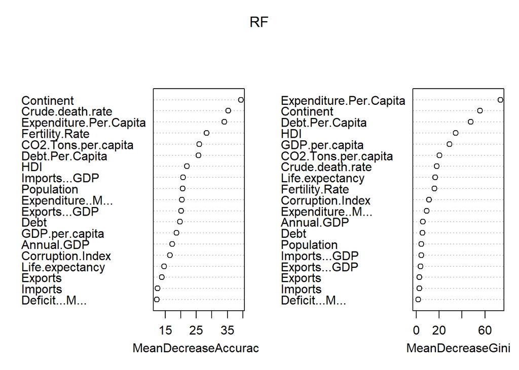

```r
##Importance Plot
varImpPlot(RF)
```

I conducted a one-way Manova test with 6 populations which are the continents in the dataset (Africa, Asia, Europe, North America, Oceania, South America), where the invidividual observations in this dataset are countries in a given year between 2002-2016. The mean vectors that are being evaluated in this one-way Manova include the variables Exports, Exports…GDP, Imports, and Imports…GDP. The null hypothesis for this test is that the population means for Exports, Exports…GDP, Imports, and Imports…GDP are equal between Continents. The alternative hypothesis is that at least two continents (populations) will have at least one different population mean value out of the variables Exports, Exports…GDP, Imports, and Imports…GDP. The Wilk’s test static calculated in this one-way Manova was 0.6387582 which converts to an F statistic of 29.30656 with the degrees of freedom (20, 4050.549). The p-value for this one-way Manova is < 2.22e-16 which is less than 0.05, so we can reject the null hypothesis. This means that at least two continents will have at least one different population mean value out of the variables Exports, Exports…GDP, Imports, and Imports…GDP. From this conclusion we have gotten from the one-way Manova test we can say that the continent a country is on does limit or expand their trade oppurtunities.

```r
##Create a dataframe with only the variables that involve trading
trade <- data %>% dplyr::select(Exports, Exports...GDP, Imports, Imports...GDP, Continent)

##Each observation from this data frame is a specific country at a specific year


lm <- lm(cbind(Exports, Exports...GDP, Imports, Imports...GDP) ~ Continent , data = trade)
manova <- Manova(lm)
summary(manova)
```

```
##
## Type II MANOVA Tests:
##
## Sum of squares and products for error:
##                     Exports Exports...GDP       Imports Imports...GDP
## Exports        8.641239e+13  1.954799e+06  8.981582e+13 -7.266915e+06
## Exports...GDP  1.954799e+06  7.421044e+01 -1.720618e+06  6.211416e+01
## Imports        8.981582e+13 -1.720618e+06  1.043708e+14 -9.558957e+06
## Imports...GDP -7.266915e+06  6.211416e+01 -9.558957e+06  6.634211e+01
##
## ------------------------------------------
##
## Term: Continent
##
## Sum of squares and products for the hypothesis:
##                    Exports Exports...GDP      Imports Imports...GDP
## Exports       1.146791e+13  9.462974e+06 1.121479e+13  8.470731e+06
## Exports...GDP 9.462974e+06  1.035425e+01 8.457726e+06  9.133974e+00
## Imports       1.121479e+13  8.457726e+06 1.163292e+13  8.521357e+06
## Imports...GDP 8.470731e+06  9.133974e+00 8.521357e+06  1.033609e+01
##
## Multivariate Tests: Continent
##                  Df test stat approx F num Df   den Df     Pr(>F)
## Pillai            5 0.4052690 27.59868     20 4896.000 < 2.22e-16 ***
## Wilks             5 0.6387582 29.30656     20 4050.549 < 2.22e-16 ***
## Hotelling-Lawley  5 0.4982120 30.37848     20 4878.000 < 2.22e-16 ***
## Roy               5 0.2909826 71.23254      5 1224.000 < 2.22e-16 ***
## ---
## Signif. codes:  0 '***' 0.001 '**' 0.01 '*' 0.05 '.' 0.1 ' ' 1
```

```r
Cluster1 <- averagecountryvalues[averagecountryvalues$Cluster == 1, c(3, 4, 14, 10, 19)]
Cluster2 <- averagecountryvalues[averagecountryvalues$Cluster == 2, c(3, 4, 14, 10, 19)]
n1 <- nrow(Cluster1)
n2 <- nrow(Cluster2)
p <- ncol(Cluster1)
t2test <- HotellingsT2Test(Cluster1, Cluster2)
t2test
```

```
##
##  Hotelling's two sample T2-test
##
## data:  Cluster1 and Cluster2
## T.2 = 6.3827, df1 = 5, df2 = 51, p-value = 0.0001127
## alternative hypothesis: true location difference is not equal to c(0,0,0,0,0)
```

```r
## Find the T2 Statistic
t2test$statistic *p *(n1 + n2 - 2) /(n1 + n2 - p -1)
```

```
##          [,1]
## [1,] 34.41645
```

From the data analysis techniques used in this report we can finally conclude on the research questions that I laid out in the begining of this report. The continent a country is on does ilmit or expand the trading oppurtunities of that country. The countries that have the furthest to go in becoming developed are Angola, Argentina, Boliva, Brazil, Cameroon, Chile, China, Colombia, Dominican Republic, Ecuador, Egypt, Ghana, Guatemala, Haiti, India, Indonesia, Ivory Coast, Kenya, Madagascar, Malawi, Malaysia, Medxico, Morocoo, Pakistan, Peru, Phillippines, romania, Senegal, South Africa, South Korea, Sri Lanka, tanzania, Thailand, Tunisia, Turkey, Uganda, Venezuela, Vietnam, and Zambia. Finally the biggest problems that developing countries are facing in becoming developed are the varaiables Annual.GDP, GDP.per.capita, Imports, Expenditure.Per.Capita, and HDI.